# A Data-Driven Review of Delphinid Skull Studies Using 3D Geometric Morphometrics

Morgane Dromby

2024-09-30

## Chapter 1

### READ ME

Project Title: A Data-Driven Review of Delphinid Skull Studies Using 3D Geometric Morphometrics

Problem Statement

This project addresses the research question of how Geometric Morphometrics (GM) has been used to understand the diversity of skull shapes in odontocetes (toothed whales), with a specific focus on the family Delphinidae. The systematic review seeks to synthesize existing literature to identify trends, biases, and key findings in the application of GM to this field.

Data Sources

The data for this systematic literature review was sourced from several well-respected academic search engines to ensure comprehensive coverage of scientific, peer-reviewed articles. The databases used were: Web of Science / ScienceDirect / Scopus / Ingenta Connect / Semantic Scholar

Methodology

A systematic literature review was conducted using a defined set of keywords: “Geometric morphometric,” “skull shape,” “odontocete,” and “delphinid.” The search was limited to articles published between 1990 and March 2021, a period that aligns with the introduction of the GM term. Only peer-reviewed studies that used 2D or 3D GM to investigate skull shape variations were included. Studies that used non-GM methods, focused on other marine mammal clades (e.g., mysticetes, pinnipeds), or examined structures other than skulls were excluded. The references from all identified publications were also reviewed to ensure no relevant studies were missed.

Key Findings

• Research Areas: The main research areas addressed in the studies were evolutionary ecology, ontogeny, sexual dimorphism, taxonomy and phylogeny, functional morphology, and population structure. A common approach was to compare skull structures between or within species, which falls under the scope of evolutionary ecology.

Tools & Technologies

This project used the following programming languages and software tools for data analysis and visualization:

• RStudio — for data visualization and figure generation using packages such as ggplot2, UpSetR, Venneuler, and the tidyverse.

• Power BI — for data cleaning and preliminary data exploration.

• Tableau — for interactive dashboard creation and visualization.

### Articles Per Year Range

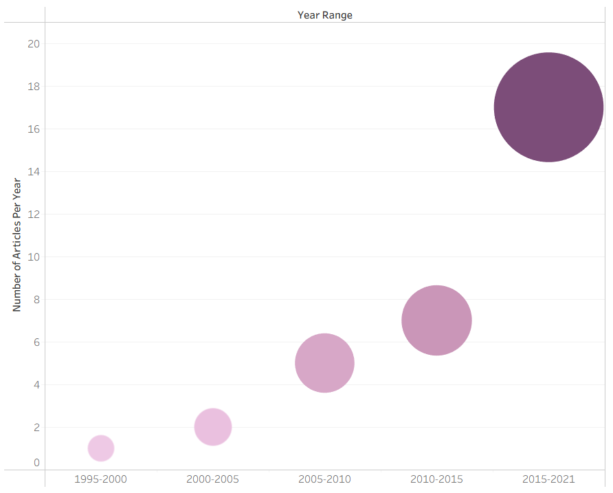

A local Image

### Articles Per Genus And Family

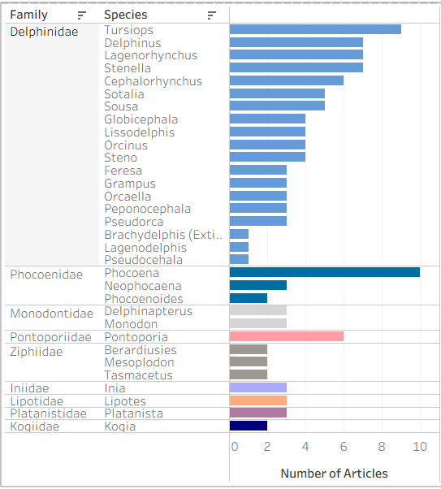

A local Image

### Venneuler Field Study

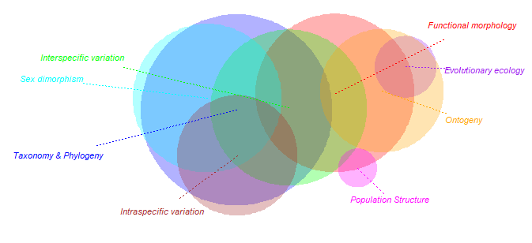

A local Image

```r
# Install The Packages

# Load The Libraries

library(ggvenn)
library(eulerr)
library(venneuler)

# Load Your File // This is a binary presence/absence table for 8 sets and 10 observations
Venn <- read.csv("../1_Data/Data_Cleaned/Venneuler_FieldStudy.csv")

## Create Euler object

# Select your columns in the table
selected_columns <- Venn[, 1:8]

# Fit stores all the information needed to draw the     Euler diagram
fit <- venneuler(selected_columns)

# Prevents labels from being written
fit$labels <- NA

## Colors and Labels
# Labels
my_labels <- c("Taxonomy & Phylogeny",
               "Functional morphology",
               "Interspecific variation",
               "Evolutionary ecology",
               "Ontogeny",
               "Sex dimorphism",
               "Intraspecific variation",
               "Population Structure")

# Colors
cols <- c("blue","red","green","purple","orange","cyan","brown","magenta")

## Plot Circles
plot(fit, col = cols, alpha = 0.3, border = NA)

# Extract centers and radii #
xs <- fit$centers[,1]
ys <- fit$centers[,2]
radii <- fit$diameters / 2

# Compute outward direction for labels #
plot_cx <- mean(range(xs))
plot_cy <- mean(range(ys))
dx <- xs - plot_cx
dy <- ys - plot_cy
dist <- sqrt(dx^2 + dy^2)
dist[dist == 0] <- 1
ux <- dx / dist
uy <- dy / dist

margin <- strheight("M") * 2.0
base_label_x <- xs + ux * (radii + margin)
base_label_y <- ys + uy * (radii + margin)

# Label adjustments
x_offset <- c(-0.1,0.1, -0.2, 0.05, 0, -0.1, 0, 0)
y_offset <- c(-0.1, 0, 0, -0.05, -0.1, 0, -0.025, 0)

# Draw leader lines and labels
for (i in 1:8) {
  factor <- 0.80
  x_end <- xs[i] + (base_label_x[i] + x_offset[i] - xs[i]) * factor
  y_end <- ys[i] + (base_label_y[i] + y_offset[i] - ys[i]) * factor
  segments(xs[i], ys[i], x_end, y_end, col = cols[i], lty = 3)

  # label
  text(base_label_x[i] + x_offset[i],
       base_label_y[i] + y_offset[i],
       my_labels[i],
       col = cols[i],
       font = 3,
       cex = 0.55)}
```

### UPSET Diagrams

```
 GEOGRAPHY
```

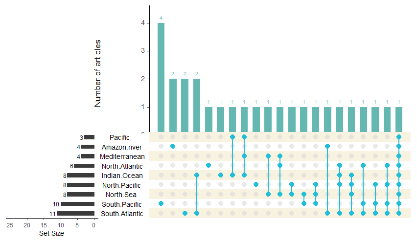

A local Image

[output not shown]

```r
# Install and load package
library("UpSetR")

# Load your Data
Geo <- read.csv ("../1_Data/Data_Cleaned/Upset_Geography.csv")

# Create UpSet plot
upset(Geo,
      nsets = 9,                      # number of sets to display
      nintersects = NA,               # show all intersections
      mb.ratio = c(0.55, 0.45),       # adjust main bar vs set size ratio
      keep.order = FALSE,
      order.by = "freq",
      decreasing = TRUE,
      matrix.color = "#22BED9",       # turquoise dots
      main.bar.color = "#64B8B1",     # deep ocean blue
      mainbar.y.label = "Number of articles",
      point.size = 2.5,               # slightly larger points
      line.size = 0.75,               # thicker connecting lines
      show.numbers = "yes",
      number.angles = 0,              # horizontal numbers
      group.by = "degree",
      shade.color = "#E9D59C",        # light seafoam shading
      shade.alpha = 0.30,
      scale.sets = "identity",
      text.scale = c(1.2, 1.2, 1, 1, 1.2, 1),  # scale text for readability
      set_size.show = TRUE,
      set_size.scale_max = 25,
      mainbar.y.max = NULL)
```

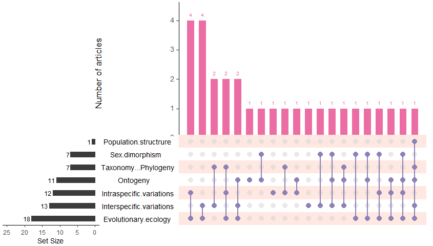

A local Image

```r
# Load your Data
FieldStudy <- read.csv ("../1_Data/Data_Cleaned/Upset_FieldStudy.csv")

# Create UpSet plot
upset(
  FieldStudy,
  nsets = 7,
  nintersects = NA,
  mb.ratio = c(0.55, 0.45),
  keep.order = FALSE,
  order.by = "freq",
  decreasing = TRUE,
  matrix.color = "#8D82B7",
  main.bar.color = "#EC6DA3",
  mainbar.y.label = "Number of articles",
  point.size = 2.5,
  line.size = 0.75,
  show.numbers = "yes",
  number.angles = 0,
  group.by = "degree",
  shade.color = "#FB8B6A",
  shade.alpha = 0.20,
  scale.sets = "identity",
  text.scale = c(1.2, 1.2, 1, 1, 1.2, 1),
  set_size.show = TRUE,
  set_size.scale_max = 25,
  mainbar.y.max = NULL)
```

### Donuts - Species By Ocean

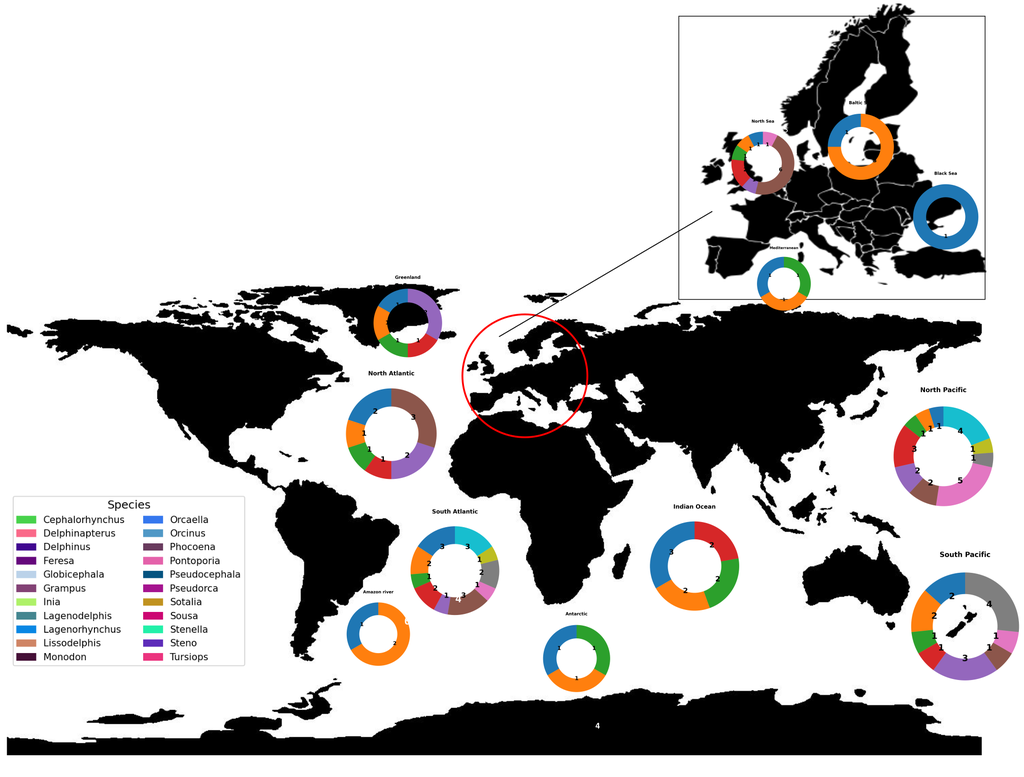

A local Image

```python
PYTHON CODING

import pandas as pd
import matplotlib.pyplot as plt
import os # We need this to handle operating system interactions like file paths

plt.rcParams['axes.titlesize'] = 45   # default title font size
plt.rcParams['axes.titleweight'] = 'bold'

outdir = '.' # Specifies that the files and graphics should be in the set directory

# The file should be in the same directory, or you need to provide the full path
df = pd.read_csv("MasterFile_Cleaned.csv")

# Split columns by slash
df["Species"] = df["Species"].str.split("/")
df["Oceans/Seas"] = df["Oceans/Seas"].str.split("/")

# Put names in different columns
df = df.explode("Species")
df["Species"] = df["Species"].str.strip()

df = df.explode("Oceans/Seas")
df["Oceans/Seas"] = df["Oceans/Seas"].str.strip()

# --- Create cross-tab table ---
species_ocean_table = pd.crosstab(df["Species"], df["Oceans/Seas"])
species_ocean_table.to_excel(os.path.join(outdir, "species_by_ocean.xlsx"))

# --- Generate donut charts per ocean ---

# --- Load the modified Excel file --- I have cleaned it based on biological knowledge

import matplotlib.patches as mpatches
import random

species_ocean_table = pd.read_excel("species_by_ocean_cleaned.xlsx", index_col=0)

plt.rcParams['axes.titlesize'] = 45   # default title font size
plt.rcParams['axes.titleweight'] = 'bold'

# Function to show counts instead of percentages
def make_autopct(values):
    def my_autopct(pct):
        total = sum(values)
        val = int(round(pct*total/100.0))
        return f"{val}"
    return my_autopct


# Get all unique species
all_species = species_ocean_table.index.tolist()


# Assign default matplotlib colors
default_colors = plt.rcParams['axes.prop_cycle'].by_key()['color']
species_colors = {species: (random.random(), random.random(), random.random()) for species in all_species}


# Create a single legend figure
legend_elements = [
    mpatches.Patch(color=color, label=species)
    for species, color in species_colors.items()
]

plt.figure(figsize=(6, 12))
plt.legend(
    handles=legend_elements,
    loc="center",
    title="Species",
    fontsize=10,
    title_fontsize=12,
    ncol=2)

plt.axis("off")  # hide empty plot
plt.tight_layout()

outdir = os.path.join(".", "donut")
os.makedirs(outdir, exist_ok=True)

plt.savefig(os.path.join(outdir, "species_legend.png"), dpi=150, transparent=True, bbox_inches="tight")
plt.close()


# 3. PLOTTING LOOP
for ocean in species_ocean_table.columns:
    counts = species_ocean_table[ocean]
    counts = counts[counts > 0]

    if counts.empty:
        continue  # skip oceans with no counts

    plt.figure(figsize=(6,6))
    wedges, texts, autotexts = plt.pie(
        counts,
        labels=None,
        autopct=make_autopct(counts),
        startangle=90,
        wedgeprops=dict(width=0.4)
    )

    outdir = os.path.join(".", "donut")
    os.makedirs(outdir, exist_ok=True)

  # Style the count labels
    plt.setp(autotexts, size=25, weight="bold", color="Black")

    plt.title(f"{ocean}", fontsize=20, fontweight="bold")
    plt.tight_layout()

    # Save with transparent background
    plt.savefig(
        os.path.join(outdir, f"donut_{ocean.replace(' ', '_')}.png"),
        dpi=150,        transparent=True
    )
    plt.close()
```

### Chord Diagram

```python
     Python codes - Matrix Preparation

import pandas as pd
import numpy as np
import matplotlib.pyplot as plt

# Load Data
FieldStudy = pd.read_csv("Upset_FieldStudy.csv")

# Get column names
columns = FieldStudy.columns.tolist()

# Compute coocurrence Matrix
co_matrix = np.dot(FieldStudy.T, FieldStudy)
np.fill_diagonal(co_matrix, 0)  # remove self-links

co_df = pd.DataFrame(co_matrix, index=columns, columns=columns)

# Export Matrix in your directory
co_df.to_csv("/mnt/c/1.MorganeCanada/Project-1-/1_Data/Data_Raw/cooccurrence_table.csv")
```

```r
 Chord Diagram with R Studio

# Install packages
install.packages("devtools")
devtools::install_github("mattflor/chorddiag")
install.packages("htmlwidgets") # Used to save the interactive plot
install.packages("circlize") # Often useful for general circular plotting

# Load the libraries
library(chorddiag)
library(htmlwidgets)
library(dplyr)

# --- DATA LOADING AND PREPARATION ---
Chord <- read.csv("../1_Data/Data_Raw/cooccurrence_table.csv", row.names = 1)
NbArticles <- read.csv("../1_Data/Data_Raw/Upset_FieldStudy.csv")

# --- GENERATE THE INTERACTIVE CHORD DIAGRAM ---
## The chorddiag function automatically uses the order of the matrix rows/columns ##

# Transform as Matrix
co_matrix <- as.matrix(Chord)

# Set your categories
categories <- colnames(co_matrix)

# Calculate totals for group label display
article_counts <- colSums(NbArticles > 0)
group_names_with_articles <- paste0(colnames(NbArticles), "   (", article_counts, ")")

# Set you Rows and Columns Names
rownames(co_matrix) <- group_names_with_articles
colnames(co_matrix) <- group_names_with_articles

# Plot the Diagram
chord_plot <- chorddiag(
data = co_matrix,
type = "directional", # Use directional for flows, even if data is symmetric
groupNames = group_names_with_articles,
groupnamePadding = 5, # Add padding between the diagram and the labels
groupPadding = 4,      # Add space between the segments (groups)
groupnameFontsize = 10,
tooltipUnit = " co-occurrences", # Customize the unit shown in the tooltip
palette = "Set3", # Use a color palette
showTicks = FALSE)

# SAVE THE PLOT AS AN INTERACTIVE HTML FILE
saveWidget(chord_plot,
         file = "chord_diagram_interactive.html")
```